# Quantmod Package Code Through

Herb Mueller

October 09, 2020

# Quantitative Financial Modeling & Trading Framework for R

I may have begun my journey into data analysis to strength my technical background and to become a better product manager, but all this time I have also wanted to create my own models to secretly get rich on the stock market. While I may not have hit on my get rich quick model yet, I did happen to find a package in R that allows me to quickly get access to stock data summaries and stock chart visualizations within the R application. This “quantmod” package is an especially powerful tool for R users that can take the data provided and use their own modeling to indentify trends within the data.

# Explaining “quantmod”

Package “quantmod” is used to easily bring financial data into R to perform further analysis on this data. In addition to bringing in finanical data, “quantmod” also has customizable charting tools to help with the visualization of the financial data.

## Installing & Loading

To begin, you will need to install the “quantmod” package and then load the “quantmod” library in your R software.

```r
install.packages("quantmod")

library(quantmod)
```

# Calling stock symbols

We will start with the basics which involves pulling in the a stock symbol. For this exercise, we will use the “getSymbols” function to call for the Tesla stock symbol (TSLA). Quantmod pulls in financial information from Yahoo by default but you can use other functions such as the “getSymbols.google” function to pull financial data from other sources.

```r
getSymbols("TSLA")
```

[output not shown]

```
## [1] "TSLA"
```

```r
head(TSLA)
```

```
##            TSLA.Open TSLA.High TSLA.Low TSLA.Close TSLA.Volume TSLA.Adjusted
## 2010-06-29     3.800     5.000    3.508      4.778    93831500         4.778
## 2010-06-30     5.158     6.084    4.660      4.766    85935500         4.766
## 2010-07-01     5.000     5.184    4.054      4.392    41094000         4.392
## 2010-07-02     4.600     4.620    3.742      3.840    25699000         3.840
## 2010-07-06     4.000     4.000    3.166      3.222    34334500         3.222
## 2010-07-07     3.280     3.326    2.996      3.160    34608500         3.160
```

With the head function, I can see the data for the first 6 available dates for the TSLA stock symbol. For each date, we have the following data.

Date - The date associated with the data

Open - The opening price of the stock on that date

High - The high trading price of the stock on that date

Low - The low trading price of the stock on that date

Close - The closing price of the stock on that date

Volume - The number of shares traded on that date

Adjusted - The adjusted closing price of the stock on that date

## Creating a data set of multiple stocks

As we begin the process of modeling, we may want to create a larger dataset with more stocks. In “quantmod” this is a simple process, we just need to create an object with the stock symbols we are interested in. For this process, I created an object called “USNEWS_Picks” that contains the ticker symbols for U.S. News and World Report’s top value stocks in 2020. I then passed this “USNEWS_Picks” object through the “getsymbols” function which then created a new “XTS” object for each ticker symbol. Finally, I merged these XTS objects into a single data frame using the following command: data.frame(as.xts(merge())).

```r
USNEWS_Picks <- (c("CF", "VIAC", "CVX", "CVS", "VTR", "VZ", "ALXN" ))
getSymbols(USNEWS_Picks)
```

```
## pausing 1 second between requests for more than 5 symbols
## pausing 1 second between requests for more than 5 symbols
## pausing 1 second between requests for more than 5 symbols
```

```
## [1] "CF"   "VIAC" "CVX"  "CVS"  "VTR"  "VZ"   "ALXN"
```

```r
USNEWS_Value_Stocks <- data.frame(as.xts(merge(CF, VIAC, CVX, CVS, VTR, VZ, ALXN)))
head(USNEWS_Value_Stocks)
```

|  | CF.Open | CF.High | CF.Low | CF.Close | CF.Volume | CF.Adjusted | VIAC.Open | VIAC.High | VIAC.Low | VIAC.Close | VIAC.Volume | VIAC.Adjusted | CVX.Open | CVX.High | CVX.Low | CVX.Close | CVX.Volume | CVX.Adjusted | CVS.Open | CVS.High | CVS.Low | CVS.Close | CVS.Volume | CVS.Adjusted | VTR.Open | VTR.High | VTR.Low | VTR.Close | VTR.Volume | … |
| --- | --- | --- | --- | --- | --- | --- | --- | --- | --- | --- | --- | --- | --- | --- | --- | --- | --- | --- | --- | --- | --- | --- | --- | --- | --- | --- | --- | --- | --- | --- |
| 2007-01-03 | 5.178 | 5.348 | 5.140 | 5.292 | 3847500 | 3.096766 | NA | NA | NA | NA | NA | NA | 72.77 | 73.22 | 70.55 | 70.97 | 12719600 | 42.66032 | 30.95 | 31.39 | 30.46 | 30.84 | 10397100 | 24.28755 | 48.32705 | 48.38415 | 47.61905 | 47.83602 | 859800 | … |
| 2007-01-04 | 5.290 | 5.378 | 5.260 | 5.350 | 2146500 | 3.130707 | NA | NA | NA | NA | NA | NA | 70.90 | 70.95 | 69.60 | 70.28 | 10825300 | 42.24556 | 31.21 | 31.23 | 30.66 | 31.00 | 9449400 | 24.41356 | 47.96163 | 47.96163 | 47.18511 | 47.80176 | 654300 | … |
| 2007-01-05 | 5.170 | 5.332 | 5.170 | 5.318 | 2165500 | 3.111982 | NA | NA | NA | NA | NA | NA | 70.28 | 71.12 | 70.12 | 70.55 | 9618000 | 42.40787 | 31.01 | 31.25 | 30.69 | 31.17 | 10817200 | 24.54744 | 47.80176 | 47.83602 | 47.05949 | 47.20795 | 719000 | … |
| 2007-01-08 | 5.318 | 5.348 | 5.218 | 5.284 | 2544500 | 3.092085 | NA | NA | NA | NA | NA | NA | 71.06 | 71.56 | 70.00 | 71.45 | 9435100 | 42.94885 | 31.51 | 31.51 | 30.75 | 31.35 | 14188500 | 24.68920 | 47.39066 | 47.39066 | 46.87678 | 47.29930 | 614300 | … |
| 2007-01-09 | 5.296 | 5.420 | 5.290 | 5.404 | 3017500 | 3.162307 | NA | NA | NA | NA | NA | NA | 70.98 | 71.34 | 69.85 | 70.63 | 10500000 | 42.45595 | 31.33 | 31.47 | 30.75 | 31.01 | 14052600 | 24.42143 | 47.56195 | 48.07583 | 46.71691 | 47.90453 | 1125500 | … |
| 2007-01-10 | 5.404 | 5.454 | 5.390 | 5.430 | 3484500 | 3.177521 | NA | NA | NA | NA | NA | NA | 69.75 | 70.31 | 68.93 | 69.41 | 11936700 | 41.72259 | 31.00 | 31.37 | 30.64 | 31.32 | 10273900 | 24.66557 | 47.69898 | 48.07583 | 47.47060 | 48.07583 | 543100 | … |

As you can see, this created a dataset where we can track the data for multiple stocks over individual days. By building a large data set like this, we can begin analyzing the data for trends that will give us an edvantage when making stock trades.

# Stock Charts

Obviously it can be quite difficult trying to identify trading trends when looking over years of data. This is where stock charts can be incredbily useful and “quantmod” has a very customizable charting tool available right in R. To get started, we are going to retrieve the stock data for General Electric (GE) and then create a chart for that stock data within R. To create a stock chart, we will use the “chart_series” function.

```r
getSymbols("GE")
```

```
## [1] "GE"
```

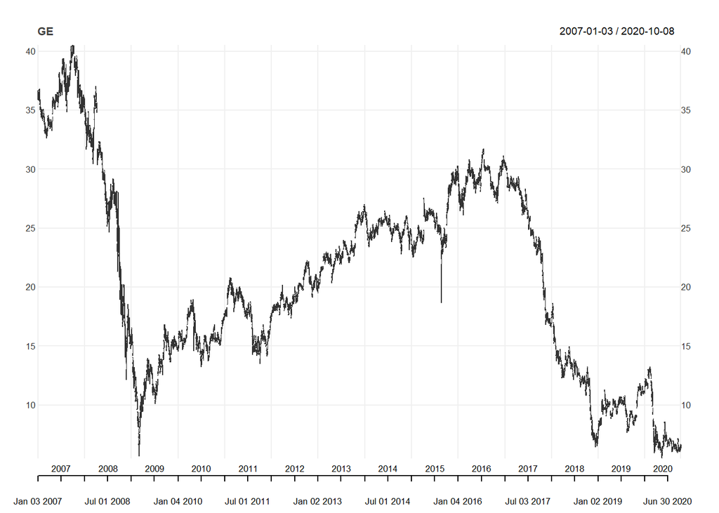

```r
chart_Series(GE)
```

Additionally, we can customize our charts and add other information that may be useful for our chart analysis. In the example below, we are using the “add_BBands” function to add bollinger bands to our chart and the “add_MACD” function to add the moving average convergence-divergence indicator.

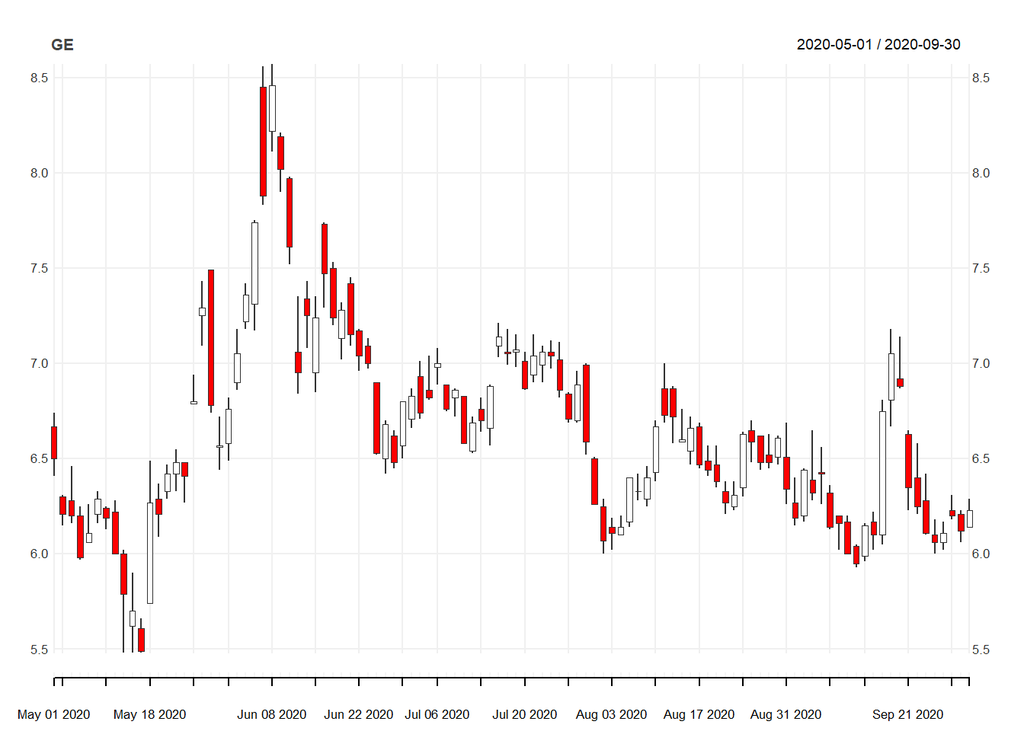

```r
chart_Series(GE, subset = "2020-5::2020-9")
```

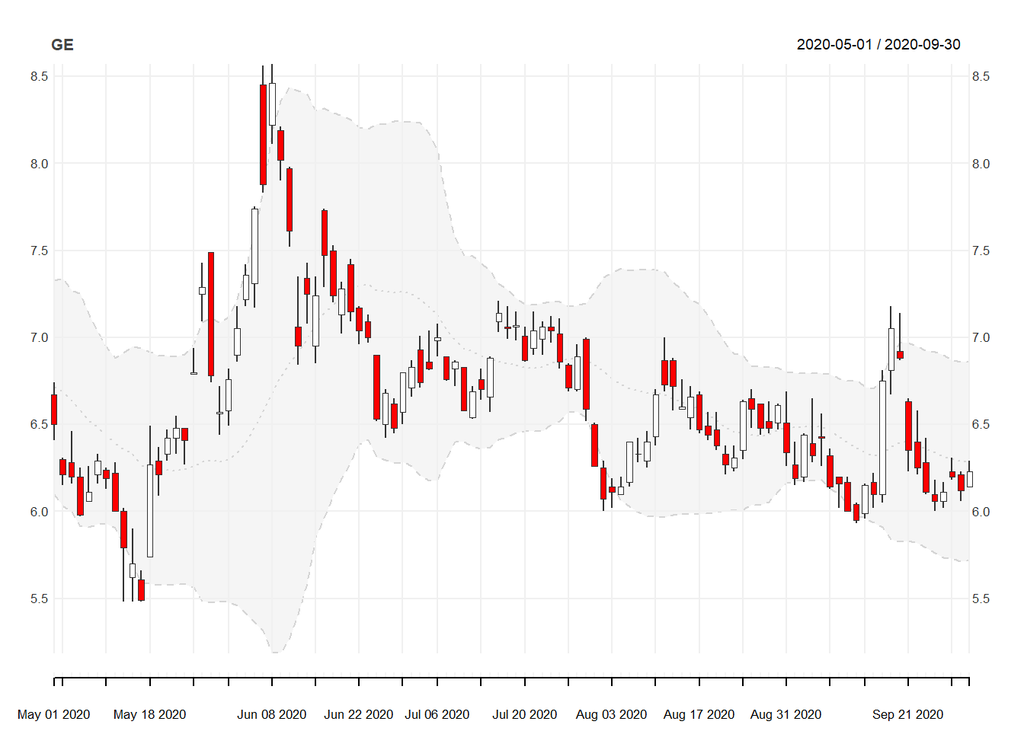

```r
add_BBands()
```

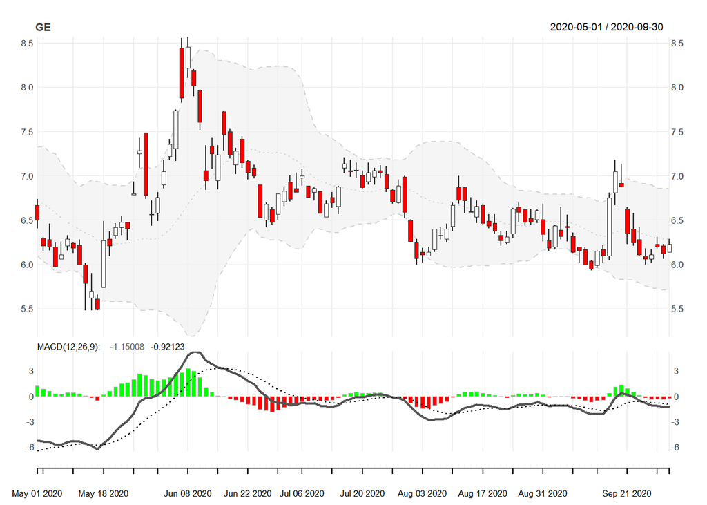

```r
add_MACD()
```

While “quantmod” is a powerful charting tool by itself, there are other packages available in R which has funcitionality that may not be available within “quantmod”. One additional package that I found through my research was the “highcharter” package that can be used in tandem with “quantmod” to make financial charts that are interactive in R. The example chart I have below can have each candlestick highlighted and the assoicated data with the candlestick can be seen when highlighted.

```r
library("highcharter")
getSymbols("AAPL")
```

```
## [1] "AAPL"
```

```r
highchart() %>%
  hc_add_series(AAPL) %>%
  hc_add_theme(hc_theme_538())
```

[interactive chart not shown]

# Sources and Resources

The following material was used to research more about the “quantmod” package and it is highly recommended for anyone that would like to learn more.

- [**CRAN - Package “quantmod”**](https://cran.r-project.org/web/packages/quantmod/quantmod.pdf)
- [**Quantmod website**](https://www.quantmod.com/)
- [**Quantmod Youtube Explainer Video**](https://www.youtube.com/watch?v=xeflRR5RKFw)